# Speech Input Corrections

June 27, 2019

# 1 Data Parsing

## 1.1 Loading Data

Filtering out invalid participants (9, 10, and 14).

```r
data_c = read.csv("parse_more.csv",sep=",") %>% filter(!participantNo %in% c(9, 10, 14))
data_c = data_c[,!names(data_c) %in% c("incorrect_fixed", "fixes", "correct", "inf", "msg", "correctMsg", "gMsg")]
data_c.kbd = filter(data_c, inputType=="Keyboard")
data_c.sr = filter(data_c, inputType=="Speech")

data_t = read.csv("parse_more_trans.csv",sep=",")
data_t = data_t[,!names(data_t) %in% c("incorrect_fixed", "fixes", "correct", "inf", "msg", "orgMsg")]
data_t$setNum = substr(data_t$setNum, 1, 1)
data_t.kbd = filter(data_t, inputType=="Keyboard")
data_t.sr = filter(data_t, inputType=="Speech")
```

## 1.2 Outlier Culling

I removed values outside of 3 standard deviations for the means of each task x method combination, for totalTime.

22 outliers identified for composition (2.04% of trials)

26 outliers identified for transcription (2.32% of trials)

## 1.3 Data Aggregation

Aggregating the cleaned data

```r
data.cr = bind_rows(data_t.clean, data_c.clean) %>% filter(corrTime > 0)
data.ncr = bind_rows(data_t.clean, data_c.clean) %>% filter(corrTime <= 0)
data = bind_rows(data_t.clean, data_c.clean)
data$hadCorrections = ifelse(data$corrTime > 0, TRUE, FALSE)

data.group.cr = summarize(group_by(data.cr, participantNo, inputType, taskType, setNum), meanInputTime = mean(inputTime), meanPrepTime = mean(prepTime), meanEntryTime = mean(entryTime), meanTotalTime = mean(totalTime), meanLen = mean(msgLen), meanWpm = mean(wpm), mean_uer = mean(uncorrected_error_rate), mean_cer= mean(corrected_error_rate), mean_bd = mean(bandwidth), meanCorrTime = mean(corrTime))

data.group.ncr = summarize(group_by(data.ncr, participantNo, inputType, taskType, setNum), meanInputTime = mean(inputTime), meanPrepTime = mean(prepTime), meanEntryTime = mean(entryTime), meanTotalTime = mean(totalTime), meanLen = mean(msgLen), meanWpm = mean(wpm), mean_uer = mean(uncorrected_error_rate), mean_cer= mean(corrected_error_rate), mean_bd = mean(bandwidth), meanCorrTime = mean(corrTime))

data.group = summarize(group_by(data, participantNo, inputType, taskType, hadCorrections), meanInputTime = mean(inputTime), meanPrepTime = mean(prepTime), meanEntryTime = mean(entryTime), meanTotalTime = mean(totalTime), meanLen = mean(msgLen), meanWpm = mean(wpm), mean_uer = mean(uncorrected_error_rate), mean_cer= mean(corrected_error_rate), mean_bd = mean(bandwidth), meanCorrTime = mean(corrTime))

data.stats.corr = data %>%
  group_by(hadCorrections) %>%
  summarize(meanInputTime = mean(inputTime), meanPrepTime = mean(prepTime), meanEntryTime = mean(entryTime), meanTotalTime = mean(totalTime), meanLen = mean(msgLen), meanWpm = mean(wpm), mean_uer = mean(uncorrected_error_rate), mean_cer= mean(corrected_error_rate), mean_bd = mean(bandwidth), meanCorrTime = mean(corrTime))

data.stats.cr = data.cr %>%
  group_by(inputType, taskType) %>%
  summarize(mIT = mean(inputTime), cuIT = ci(inputTime)[3], clIT = ci(inputTime)[2], sdIT = sd(inputTime),
            mPT = mean(prepTime), cuPT = ci(prepTime)[3], clPT = ci(prepTime)[2], sdPT = sd(prepTime),
            mET = mean(entryTime), cuET=ci(entryTime)[3], clET = ci(entryTime)[2], sdET = sd(entryTime),
            mTT = mean(totalTime), cuTT = ci(totalTime)[3], clTT = ci(totalTime)[2], sdTT = sd(totalTime),
            mCT = mean(corrTime), cuCT = ci(corrTime)[3], clCT = ci(corrTime)[2], sdCT = sd(corrTime),
            mWpm = mean(wpm), cuWpm = ci(wpm)[3], clWpm = ci(wpm)[2], sdWpm = sd(wpm),
            m_uer = mean(uncorrected_error_rate), cu_uer = ci(uncorrected_error_rate)[3], cl_uer = ci(uncorrected_error_rate)[2], sd_uer = sd(uncorrected_error_rate),
            m_cer= mean(corrected_error_rate), cu_cer = ci(corrected_error_rate)[3], cl_cer = ci(corrected_error_rate)[2], sd_cer = sd(corrected_error_rate))

data.stats.ncr = data.ncr %>%
  group_by(inputType, taskType) %>%
  summarize(mIT = mean(inputTime), cuIT = ci(inputTime)[3], clIT = ci(inputTime)[2], sdIT = sd(inputTime),
            mPT = mean(prepTime), cuPT = ci(prepTime)[3], clPT = ci(prepTime)[2], sdPT = sd(prepTime),
            mET = mean(entryTime), cuET=ci(entryTime)[3], clET = ci(entryTime)[2], sdET = sd(entryTime),
            mTT = mean(totalTime), cuTT = ci(totalTime)[3], clTT = ci(totalTime)[2], sdTT = sd(totalTime),
            mCT = mean(corrTime), cuCT = ci(corrTime)[3], clCT = ci(corrTime)[2], sdCT = sd(corrTime),
            mWpm = mean(wpm), cuWpm = ci(wpm)[3], clWpm = ci(wpm)[2], sdWpm = sd(wpm),
            m_uer = mean(uncorrected_error_rate), cu_uer = ci(uncorrected_error_rate)[3], cl_uer = ci(uncorrected_error_rate)[2], sd_uer = sd(uncorrected_error_rate),
            m_cer= mean(corrected_error_rate), cu_cer = ci(corrected_error_rate)[3], cl_cer = ci(corrected_error_rate)[2], sd_cer = sd(corrected_error_rate))

data.long = melt(data.group, id = c("participantNo", "inputType", "taskType", "hadCorrections", "meanInputTime", "meanPrepTime", "meanWpm", "meanTotalTime", "meanEntryTime", "meanLen", "mean_uer", "mean_cer", "mean_bd", "meanCorrTime"))

data.long$participantNo <- factor(data.long$participantNo)
data.long$inputType <- factor(data.long$inputType)
data.long$hadCorrections<- factor(data.long$hadCorrections)
data.long$taskType <- factor(data.long$taskType)
```

# 2 Input Time

## 2.1 Chart

```r
kable(dplyr::select(data.stats.cr, inputType, taskType, mIT, sdIT))
```

| inputType | taskType | mIT | sdIT |
| --- | --- | --- | --- |
| Keyboard | Composition | 25573.84 | 13375.685 |
| Keyboard | Transcription | 16957.98 | 6529.331 |
| Speech | Composition | 12351.15 | 8138.598 |
| Speech | Transcription | 9393.33 | 5090.325 |

```r
kable(dplyr::select(data.stats.ncr, inputType, taskType, mIT, sdIT))
```

| inputType | taskType | mIT | sdIT |
| --- | --- | --- | --- |
| Keyboard | Composition | 14955.646 | 6918.168 |
| Keyboard | Transcription | 12064.190 | 4961.258 |
| Speech | Composition | 5024.066 | 3534.132 |
| Speech | Transcription | 3667.119 | 1647.765 |

## 2.2 Bar Graph

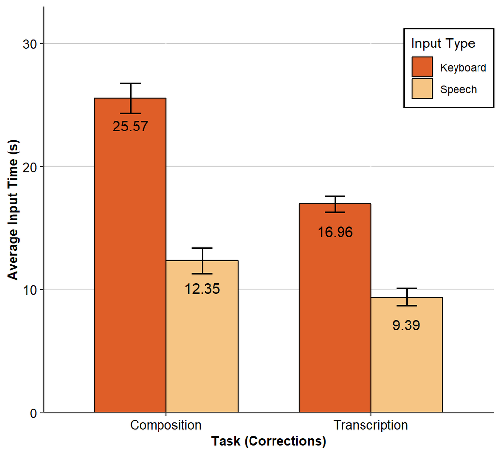

```r
createPlot(data.stats.cr, "mIT", "clIT", "cuIT", 3, 0.9, 0.85, "Average Input Time (s)", x_axis="Task (Corrections)")
```

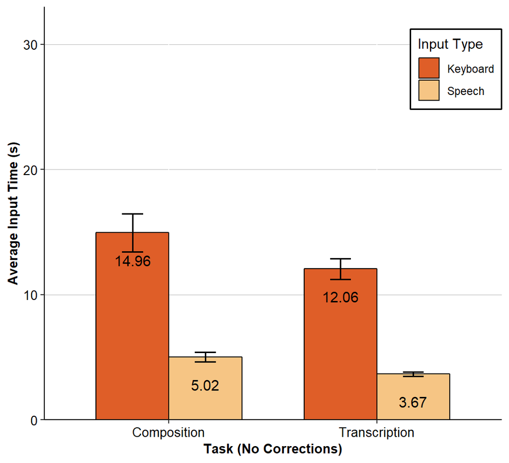

```r
createPlot(data.stats.ncr, "mIT", "clIT", "cuIT", 3, 0.9, 0.85, "Average Input Time (s)", x_axis="Task (No Corrections)")
```

## 2.3 Effects of Input Type and Task Type

### 2.3.1 Normality Check

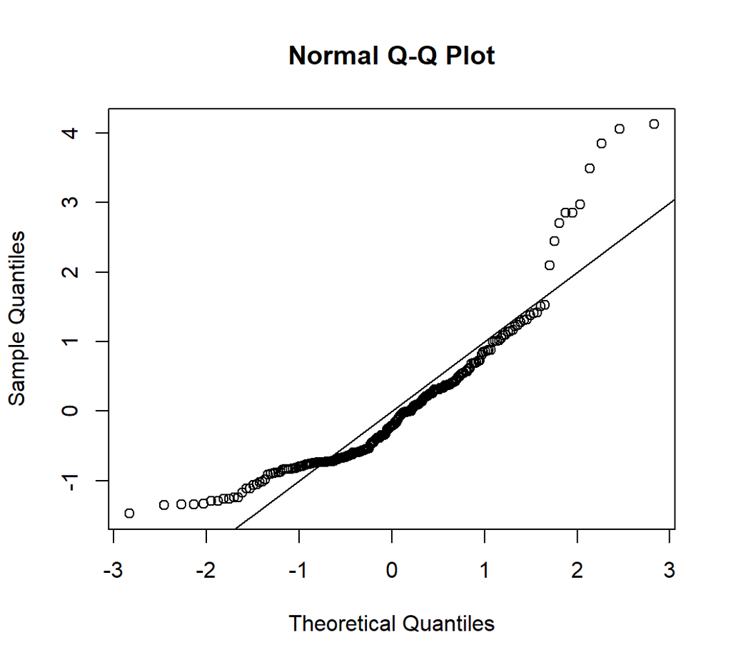

```r
m <- aov(meanInputTime ~ hadCorrections, data=data.long)
pander(normalCheck(m))
```

Shapiro-Wilk normality test

data: res W = 0.87253, p-value = 2.015e-12

Shapiro-Wilk normality test: `res`

| Test statistic | P value |
| --- | --- |
| 0.8725 | 2.015e-12 * * * |

The data is not normally distributed.

### 2.3.2 Box-Cox Transformation

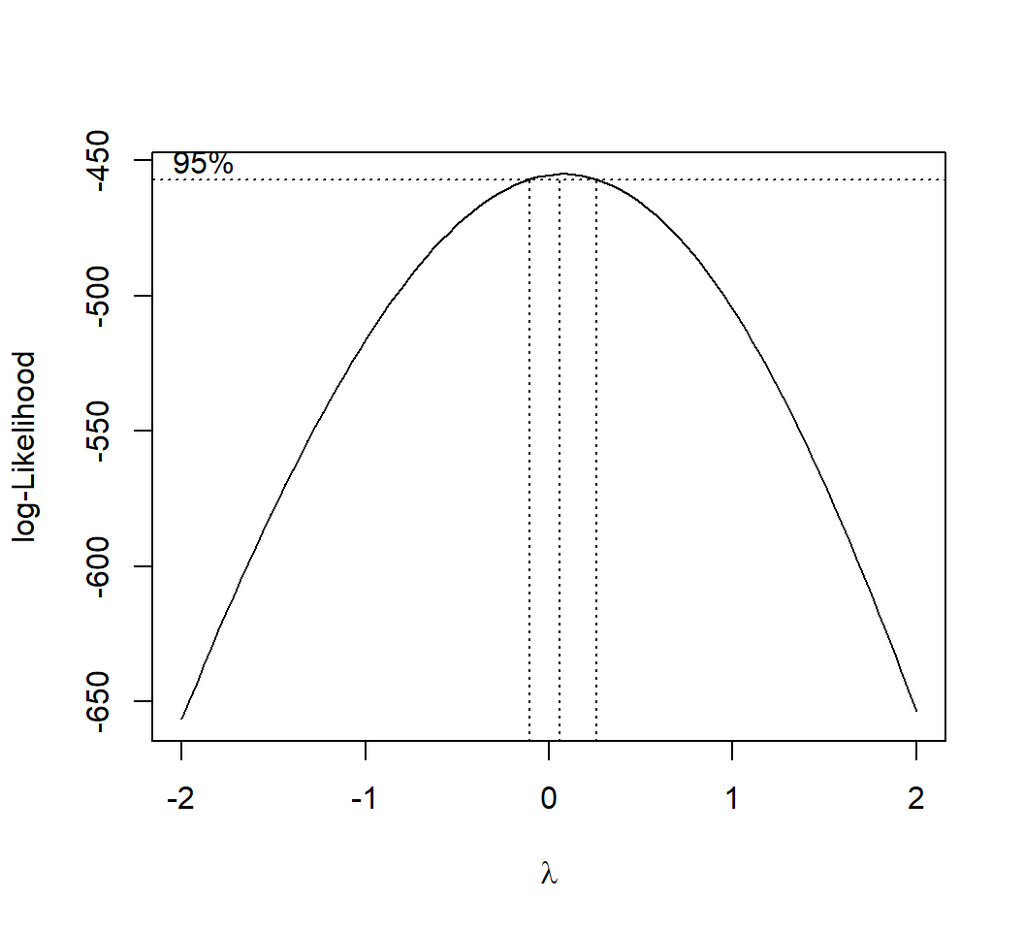

```r
boxcox(meanInputTime ~ hadCorrections, data=data.long, plotit=T)
```

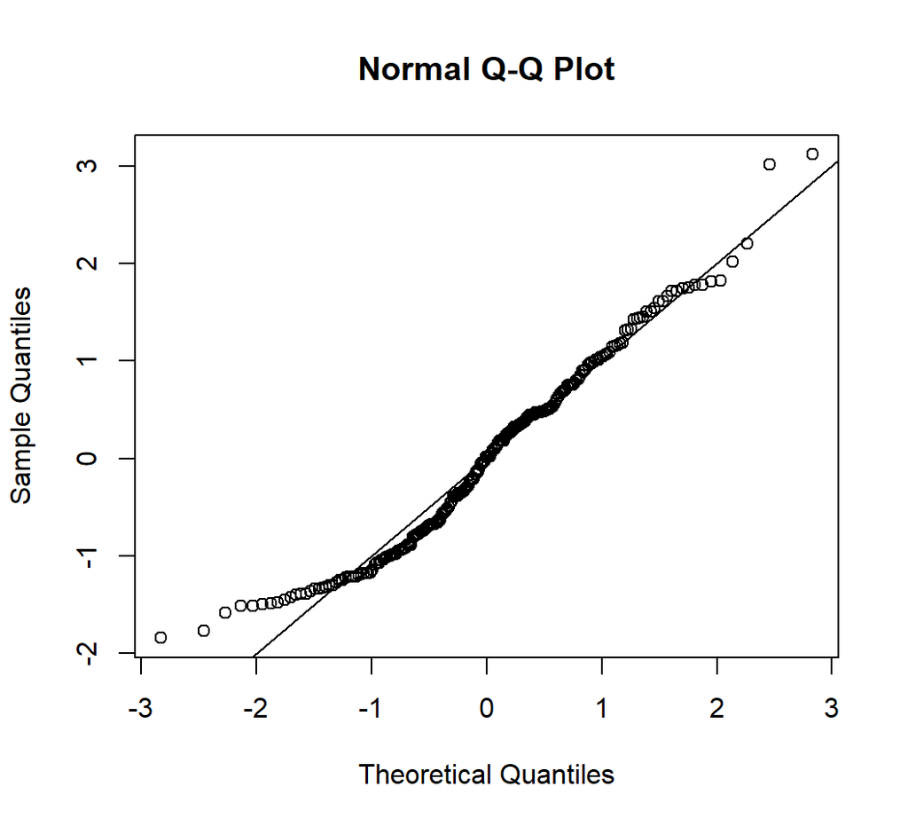

```r
datatr = data.long %>%
    mutate(meanInputTime = meanInputTime^(0.1))

m <- aov(meanInputTime ~ hadCorrections, data=datatr)
pander(normalCheck(m))
```

Shapiro-Wilk normality test

data: res W = 0.97051, p-value = 0.0001877

Shapiro-Wilk normality test: `res`

| Test statistic | P value |
| --- | --- |
| 0.9705 | 0.0001877 * * * |

### 2.3.3 Repeated measures ANOVA on transformed data

```r
anova = ezANOVA(datatr, dv=.(meanInputTime), wid=.(participantNo), within=.(hadCorrections), detailed=TRUE)
# # kable(anova$`Mauchly's Test for Sphericity`)
# # kable(anova$`Sphericity Corrections`)
# # kable(anova$ANOVA)
anova_apa = anova_apa(anova, sph_corr ="gg", es = "ges", print=FALSE)
input = anova_apa$text[2]
kable(anova_apa)
```

| effect | text |
| --- | --- |
| (Intercept) | F(1, 27) = 71532.49, p < .001, getasq > .99 |
| hadCorrections | F(1, 27) = 200.80, p < .001, getasq = .71 |

### 2.3.4 Post-hoc analysis

```r
t <- TukeyHSD(m)
kable(t$`hadCorrections`)
```

|  | diff | lwr | upr | p adj |
| --- | --- | --- | --- | --- |
| TRUE-FALSE | 0.1774333 | 0.1383645 | 0.2165021 | 0 |

```python
s = "There was a significant main effect of corrections on Box-Cox transformed \\m{Input Time} (%s)." % (parseAnova(r.input))
writeToFile(s, "corr_inputtime.tex")
```

# 3 Prep Time

## 3.1 Chart

```r
kable(dplyr::select(data.stats.cr, inputType, taskType, mPT, sdPT))
```

| inputType | taskType | mPT | sdPT |
| --- | --- | --- | --- |
| Keyboard | Composition | 5439.669 | 5471.3541 |
| Keyboard | Transcription | 1160.756 | 659.3966 |
| Speech | Composition | 13317.829 | 8632.3059 |
| Speech | Transcription | 3469.103 | 1497.3495 |

```r
kable(dplyr::select(data.stats.ncr, inputType, taskType, mPT, sdPT))
```

| inputType | taskType | mPT | sdPT |
| --- | --- | --- | --- |
| Keyboard | Composition | 4058.305 | 3797.520 |
| Keyboard | Transcription | 1085.345 | 494.217 |
| Speech | Composition | 12315.169 | 8809.397 |
| Speech | Transcription | 3524.771 | 1212.575 |

## 3.2 Bar Graph

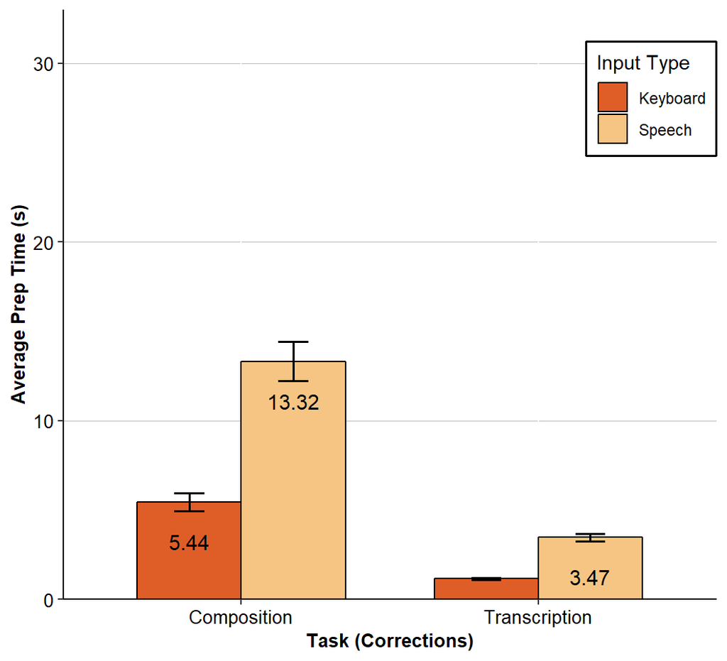

```r
createPlot(data.stats.cr, "mPT", "clPT", "cuPT", 3, 0.9, 0.85, "Average Prep Time (s)", x_axis="Task (Corrections)")
```

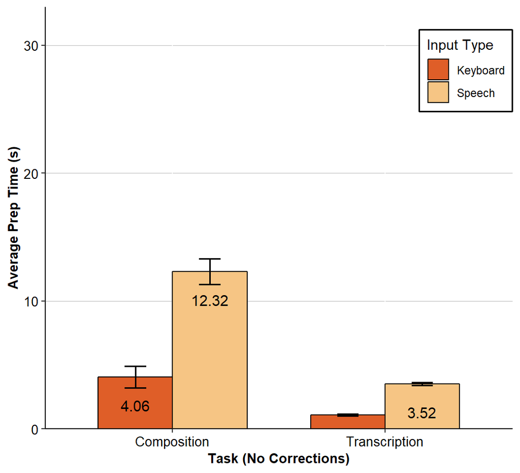

```r
createPlot(data.stats.ncr, "mPT", "clPT", "cuPT", 3, 0.9, 0.85, "Average Prep Time (s)", x_axis="Task (No Corrections)")
```

## 3.3 Effects of Input Type and Task Type

### 3.3.1 Normality Check

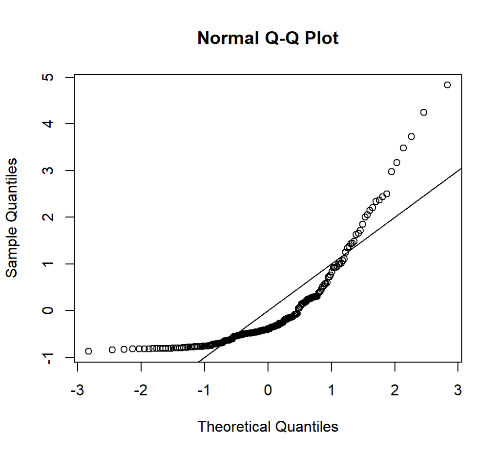

```r
m <- aov(meanPrepTime ~ hadCorrections, data=data.long)
pander(normalCheck(m))
```

Shapiro-Wilk normality test

data: res W = 0.75056, p-value < 2.2e-16

Shapiro-Wilk normality test: `res`

| Test statistic | P value |
| --- | --- |
| 0.7506 | 1.069e-17 * * * |

The data is not normally distributed.